# Visualize Continuous Data

## Today’s Learning Goals

- Compute numeric summaries for customer groups.
- Choose plots to compare distributions and relationships involving continuous variables.
- Parse review dates and summarize ratings over time.
- Combine categorical and continuous evidence in a regional customer report.

## Marketing Analytics Process

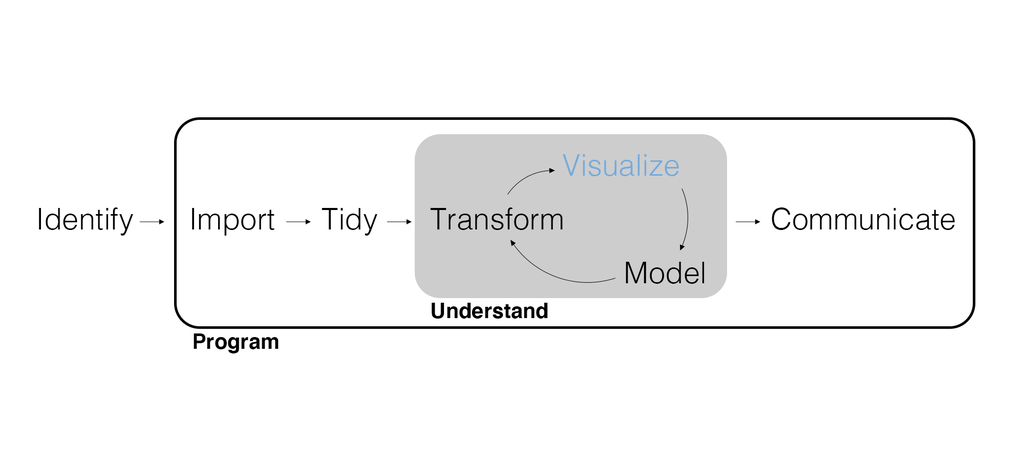

[figure not shown]

## Continuous Data

Remember that summarizing data is initially all about discovery, the heart of **exploratory data analysis**.

- Computing *statistics* (i.e., numerical summaries).
- *Visualizing* data (i.e., graphical summaries).

How we summarize depends on whether the data is *discrete* or **continuous**.

- Continuous measurements can take values along a range; we use income and credit scores as examples.
- Numeric data can also be **discrete**, such as purchase counts or star ratings.
- A numeric storage type in R does not tell us whether a variable is continuous.

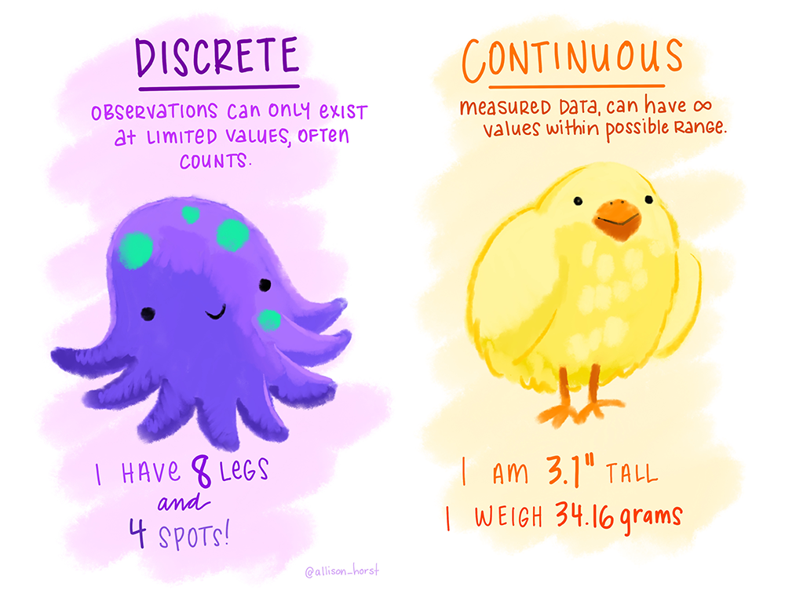

## Inspect Continuous Variables

What variables are *continuous*? What are their data types?

```r
library(tidyverse)
customer_data <- read_csv("customer_data.csv", show_col_types = FALSE)
glimpse(customer_data, width = 60)
```

```
## Rows: 10,531
## Columns: 14
## $ customer_id    <dbl> 1001, 1002, 1003, 1004, 1005, 1006,…
## $ birth_year     <dbl> 1971, 1970, 1988, 1984, 1987, 1994,…
## $ gender         <chr> "Female", "Female", "Male", "Other"…
## $ income         <dbl> 73000, 31000, 35000, 64000, 58000, …
## $ credit         <dbl> 742.0827, 749.3514, 542.2399, 573.9…
## $ married        <chr> "No", "Yes", "No", "Yes", "No", "Ye…
## $ college_degree <chr> "No", "No", "No", "Yes", "Yes", "Ye…
## $ region         <chr> "South", "West", "South", "Midwest"…
## $ state          <chr> "DC", "WA", "AR", "MN", "HI", "MN",…
## $ review_id      <dbl> 933551, NA, NA, NA, 501318, 109125,…
## $ star_rating    <dbl> 4, NA, NA, NA, 5, 2, NA, 5, NA, 5, …
## $ review_time    <chr> "06 11, 2015", NA, NA, NA, "03 25, …
## $ review_title   <chr> "Four Stars", NA, NA, NA, "Great Pr…
## $ review_text    <chr> "everything's fine", NA, NA, NA, "I…
```

## Summarize Continuous Data

One common statistic for a continuous variable is a **mean**.

```r
customer_data |>
  summarize(avg_income = mean(income))
```

```
## # A tibble: 1 × 1
##   avg_income
##        <dbl>
## 1    138623.
```

Note that `summarize()` can accommodate all sort of calculations - similar to `mutate()`. What is the main difference between `summarize()` and `mutate()`?

## Your Turn!

### Average Income and Credit

Use the customer data to display a one-row data frame with the mean income and mean credit score. Name the columns `avg_income` and `avg_credit`.

**Expected output:**

```
## # A tibble: 1 × 2
##   avg_income avg_credit
##        <dbl>      <dbl>
## 1    138623.       667.
```

We can also compute the **mode**, **median**, **variance**, **standard deviation**, **minimum**, **maximum**, **sum**, etc.

## Your Turn!

Use the customer data and the filter() and summarize() functions to display a data frame with the minimum, maximum, and median income for married customers.

**Expected output:**

```
## # A tibble: 1 × 3
##   min_income max_income median_income
##        <dbl>      <dbl>         <dbl>
## 1      18000     362000        149000
```

## Code Solution

```r
customer_data |>
  filter(married == 'Yes')|>
  summarize(
    min_income = min(income),
    max_income = max(income),
    median_income = median(income)
  )
```

## Visualize Data

Recall that {ggplot2} provides a consistent **grammar of graphics** built with **layers**.

1. Data – Data to visualize.
2. Aesthetics – Or “aes,” mapping graphical elements to data.
3. Geometry – Or “geom,” the kind of graph representing the data.
4. Facets, Labels, Scales, etc.

## Visualize Continuous Data

Let’s plot the **distribution** of income.

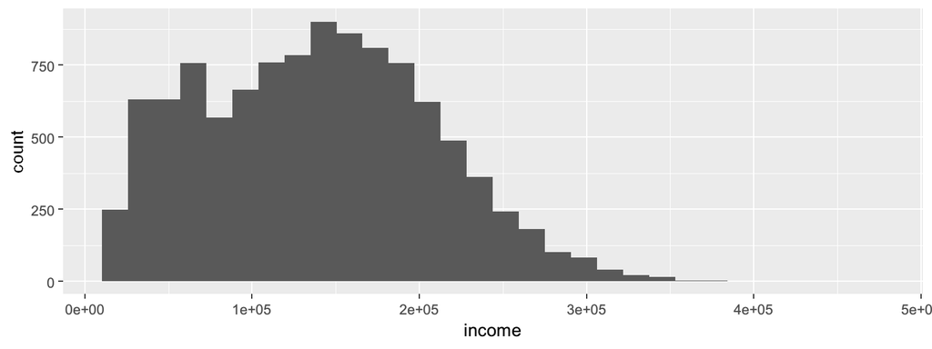

```r
customer_data |>
  ggplot(aes(x = income)) +
  geom_histogram()
```

Visualize the relationship between `income` and `credit`.

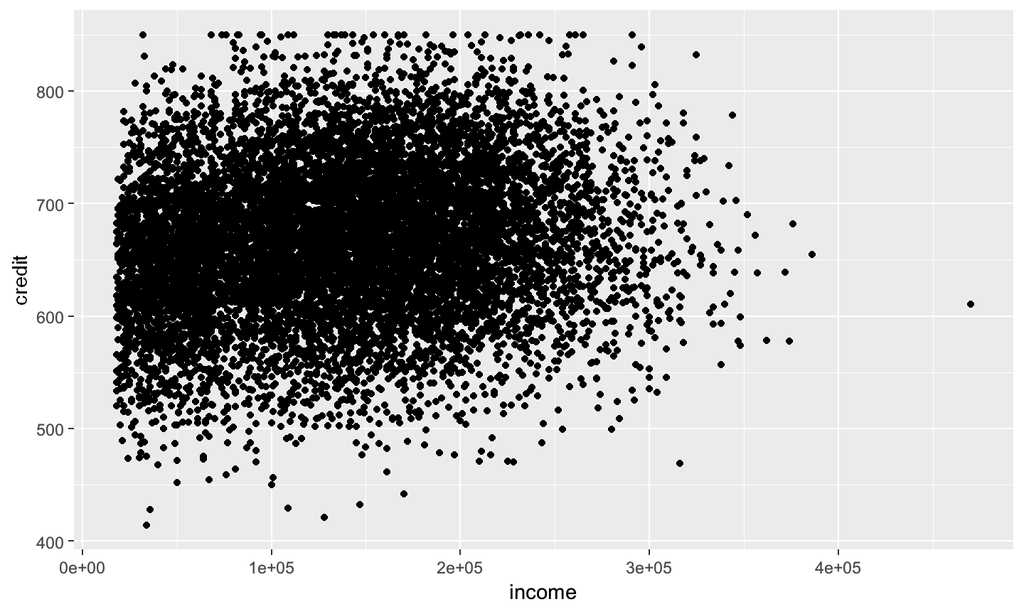

```r
customer_data |>
  ggplot(aes(x = income, y = credit)) +
  geom_point()
```

Visualize the relationship between `star_rating` and `income`.

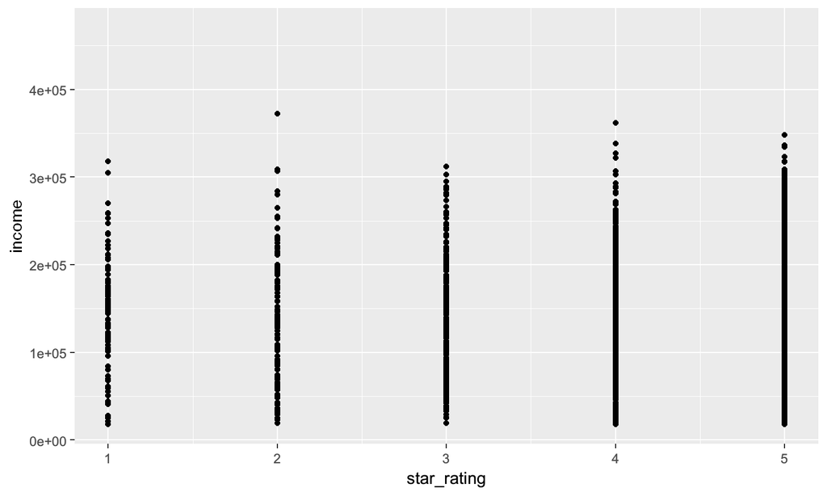

```r
customer_data |>
  ggplot(aes(x = star_rating, y = income)) +
  geom_point()
```

What do we do if there is **overplotting**? There’s a geom for that (`geom_jitter()`).

Let’s do the following:

- Drop the missing data before plotting.
- Play with the `size` and `alpha` geom arguments.
- Add a `geom_smooth()` layer.
- Facet-wrap the plot by `region`.
- Complete the plot with labels.

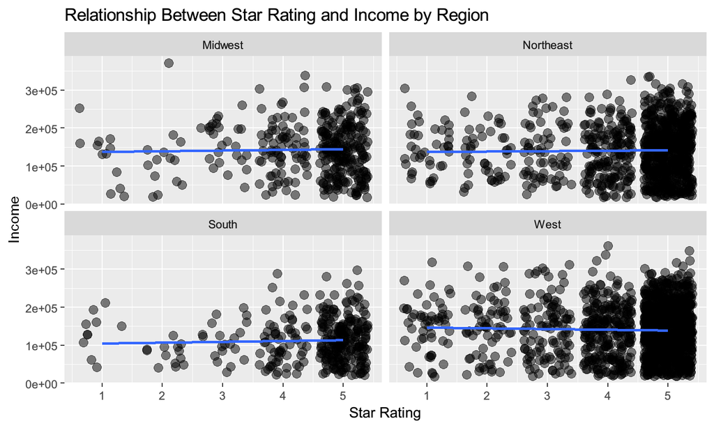

```r
customer_data |>
  drop_na(star_rating) |>
  ggplot(aes(x = star_rating, y = income)) +
  geom_jitter(size = 3, alpha = 0.5) +
  geom_smooth(method = "lm", se = FALSE) +
  facet_wrap(~ region) +
  labs(
    title = "Relationship Between Star Rating and Income by Region",
    x = "Star Rating",
    y = "Income"
  )
```

## Summarize Continuous and Discrete Data

**Grouped summaries** provide a powerful solution for computing continuous statistics across discrete categories.

```r
customer_data |>
  group_by(gender) |>
  summarize(
    n = n(),
    avg_income = mean(income),
    avg_credit = mean(credit)
  )
```

```
## # A tibble: 3 × 4
##   gender     n avg_income avg_credit
##   <chr>  <int>      <dbl>      <dbl>
## 1 Female  5219    130685.       668.
## 2 Male    4214    146861.       666.
## 3 Other   1098    144735.       665.
```

## Counts Are Grouped Summaries

`group_by()` defines groups for later operations without removing rows; `facet_wrap()` displays groups in separate plot panels.

`count()` is a shortcut for a grouped summary using `n()`. These two expressions produce the same table:

```r
customer_data |>
  group_by(gender) |>
  summarize(
    n = n()
  )
```

```r
customer_data |>
  count(gender)
```

```
## # A tibble: 3 × 2
##   gender     n
##   <chr>  <int>
## 1 Female  5219
## 2 Male    4214
## 3 Other   1098
```

We can group by more than one discrete variable.

```r
customer_data |>
  group_by(gender, region) |>
  summarize(
    n = n(),
    avg_income = mean(income),
    avg_credit = mean(credit),
    .groups = "drop"
  ) |>
  arrange(desc(avg_income))
```

```
## # A tibble: 12 × 5
##    gender region        n avg_income avg_credit
##    <chr>  <chr>     <int>      <dbl>      <dbl>
##  1 Other  Midwest     124    154637.       663.
##  2 Male   Midwest     420    152467.       666.
##  3 Other  Northeast   337    150564.       665.
##  4 Male   Northeast  1285    150498.       665.
##  5 Male   West       2079    149453.       667.
##  6 Other  West        519    144420.       667.
##  7 Female Midwest     557    134083.       671.
##  8 Female West       2497    133819.       668.
##  9 Female Northeast  1602    133333.       669.
## 10 Other  South       118    119068.       660.
## 11 Male   South       430    117988.       669.
## 12 Female South       563    105888.       664.
```

`.groups` controls how the result stays grouped—not which groups we summarize.

We can also use `slice_*()` functions along with `group_by()`.

```r
customer_data |>
  group_by(gender, region) |>
  slice_max(income, n = 3)
```

```
## # A tibble: 36 × 14
## # Groups:   gender, region [12]
##    customer_id birth_year gender income credit married college_degree region
##          <dbl>      <dbl> <chr>   <dbl>  <dbl> <chr>   <chr>          <chr>
##  1        6119       1984 Female 315000   698. No      Yes            Midwest
##  2        1299       1992 Female 306000   610. No      Yes            Midwest
##  3        7139       1957 Female 302000   727. No      Yes            Midwest
##  4        1040       1993 Female 356000   672. Yes     Yes            Northeast
##  5        6503       1997 Female 348000   599. No      Yes            Northeast
##  6       11249       1992 Female 343000   620. No      Yes            Northeast
##  7        2075       1989 Female 374000   578. No      Yes            South
##  8        7128       1966 Female 301000   708. Yes     Yes            South
##  9        4756       1977 Female 293000   790. No      Yes            South
## 10        7366       1993 Female 376000   682. No      Yes            West
## # ℹ 26 more rows
## # ℹ 6 more variables: state <chr>, review_id <dbl>, star_rating <dbl>,
## #   review_time <chr>, review_title <chr>, review_text <chr>
```

## Time Series Data

We often want to see how a variable changes over time: a **time series**. However, dates and times can be tricky.

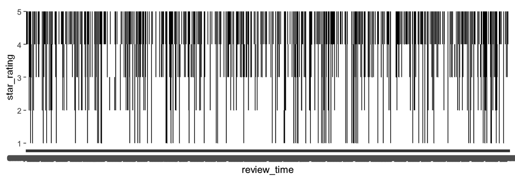

```r
customer_data |>
  ggplot(aes(x = review_time, y = star_rating)) +
  geom_line()
```

## Parse Review Dates

There’s a package for that: {lubridate}.

```r
rating_data <- customer_data |>
  drop_na(star_rating) |>
  select(review_time, star_rating) |>
  mutate(review_time = mdy(review_time))

print(rating_data, n = 3)
```

```
## # A tibble: 3,159 × 2
##   review_time star_rating
##   <date>            <dbl>
## 1 2015-06-11            4
## 2 2008-03-25            5
## 3 2013-06-07            2
## # ℹ 3,156 more rows
```

[figure not shown]

## Wait…Why Does This Plot Still Look Bad?

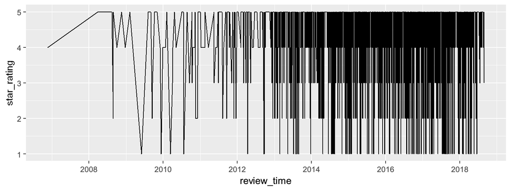

```r
rating_data |>
  ggplot(aes(x = review_time, y = star_rating)) +
  geom_line()
```

## Visualize Grouped Summaries

Let’s summarize the data by a period of time and then plot the time series.

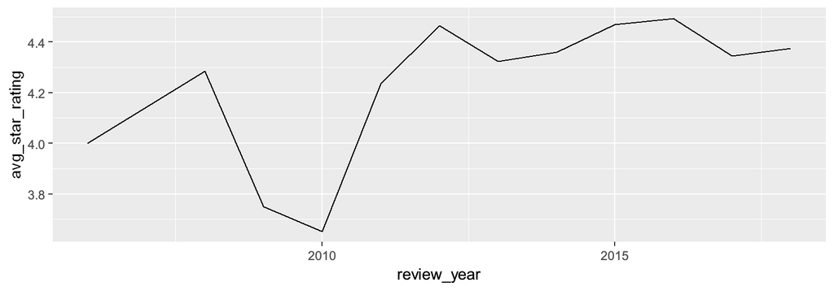

```r
rating_data |>
  mutate(review_year = year(review_time)) |>
  group_by(review_year) |>
  summarize(avg_star_rating = mean(star_rating)) |>
  ggplot(aes(x = review_year, y = avg_star_rating)) +
  geom_line()
```

## Visualize Continuous and Discrete Data

Just like there are geoms for visualizing continuous or discrete data, there are geoms for visualizing the relationship between continuous and discrete data.

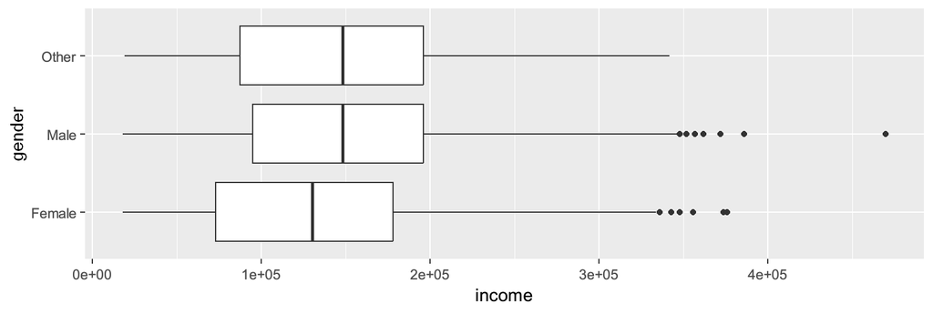

```r
customer_data |>
  ggplot(aes(x = income, y = gender)) +
  geom_boxplot()
```

## Your Turn!

Create a box plot of the distribution of credit scores for the married vs. unmarried customers. Include labels and a title!

**Expected output:**

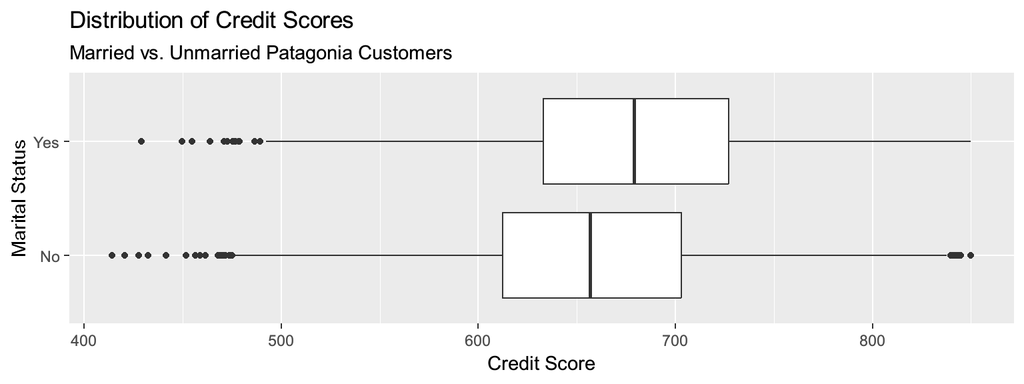

## Code Solution

```r
customer_data |>
  ggplot(aes(x = credit, y = married)) +
  geom_boxplot() +
  labs(x = 'Credit Score', y = 'Marital Status',
       title = 'Distribution of Credit Scores',
       subtitle = 'Married vs. Unmarried Patagonia Customers')
```

## We Can Also Use Density Plots

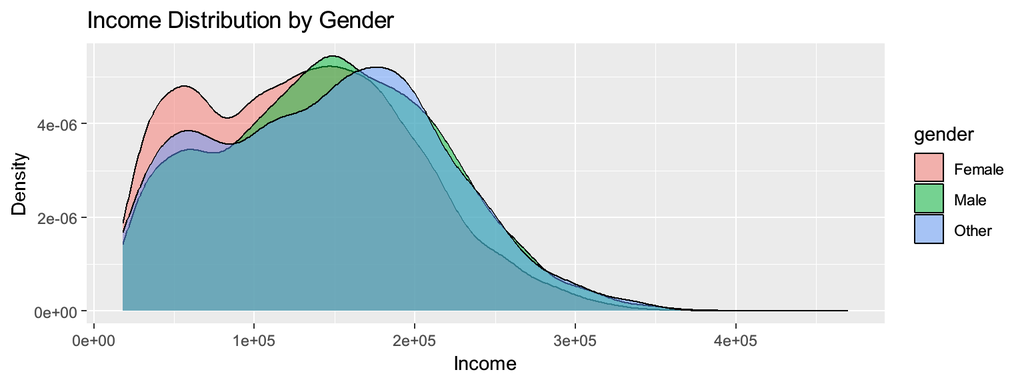

```r
customer_data |>
  ggplot(aes(x = income, fill = gender)) +
  geom_density(alpha = 0.5) +
  labs(x = "Income",
       y = "Density",
       title = "Income Distribution by Gender")
```

## Live Coding

Suppose your client, Patagonia, is interested in increasing customer engagement by offering a promotion to customers who leave a review. Can you uncover any variables that are related to whether a customer is more or less likely to leave a review?

- What should count as leaving a review for this analysis?
- Would an observed association tell us whether the promotion will increase engagement? Why or why not?

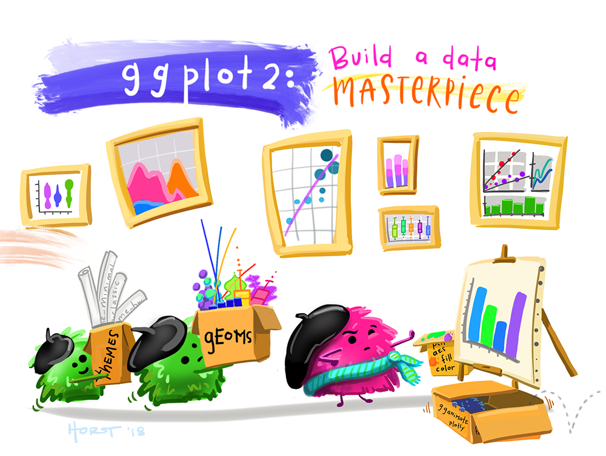

## Wrapping Up

*Summary*

- Computed grouped summaries.
- Practiced plotting with {ggplot2}, including some advanced options.

*Next Time*

- Creating reports (and almost anything else) using Quarto.
- Tidying data and the philosophy behind “tidy” data.

*Supplementary Material*

- *R for Data Science (2e)*: [10 Exploratory data analysis](https://r4ds.hadley.nz/EDA.html) and [17 Dates and times](https://r4ds.hadley.nz/datetimes.html).
- Review: [3 Data transformation](https://r4ds.hadley.nz/data-transform.html), section 3.5 Groups, including grouped summaries.

*Artwork by @allison_horst*

## Exercise 3: Regional Customer Profiles

Patagonia wants to understand how customer profiles and purchase activity differ across U.S. regions before planning regional marketing messages.

Use `customer_data.csv` and `store_transactions.csv` to prepare one short client report. The files describe the same customers, identified by `customer_id`. Purchase activity means the number of purchases in December 2018 (`dec_2018`), the latest month in these historical transaction data.

Choose one discrete customer characteristic and one continuous characteristic, such as income or credit score. Use `region` as the comparison groups, rather than as the characteristic itself. Decide which analysis operations and chart forms will answer the client’s question.

## Exercise 3: The Client Report

Include:

- A count table and a clearly labeled chart comparing your discrete characteristic across regions.
- A numeric summary describing your continuous characteristic and December 2018 purchase activity in each region.
- A clearly labeled chart comparing the distribution of your continuous characteristic across regions.
- One finding that connects your discrete and continuous evidence to regional messaging, with purchase activity as context, and one limitation of that conclusion.

Submit a Word document rendered from Quarto containing your code, tables, charts, and interpretation. Use the tidyverse and the coding conventions practiced in class. Choose and justify your approach; different defensible analyses are welcome.